# Časové řady

Joseph Bear

Abstract

V tomto dokumentu najdete praktické zpracování a ukázky cvičení a teorie týkající se časových řad. Každé téma je pečlivě vysvětleno a doplněno o konkrétní příklady, které ilustrují teorii v praxi. Pro každý koncept je uvedeno, jaký je jeho cíl, jak správně vybrat vhodný postup na základě teorie a jak jej prakticky implementovat v kódu.  
Jednoduše řečeno - Easy vysvětlená teorie + ukázky kódu.

# **Ůvod**

## Časová řada

- soubor pozorování jedné náhodné veličiny
- pozorování závislá na čase
- intervaly mezi měřeními jsou stejné
- **Cíle:**
  - Pochopení vlastností řady (sezónnost, trend, cykličnost, závislosti pozorování, …)
  - Předpovědi z minulých hodnot a vlastností
  - Pochopení závislostí různých časových řad
- Řada se řídí jedním z modelů:
  - **Aditivní model**
    - Předpokládá, že jednotlivé složky časové řady jsou sečteny dohromady.
    - Lineární vztah složek
  - **Multiplikativní model**
    - Předpokládá, že jednotlivé složky časové řady se navzájem násobí.
    - Nelineární vztah složek

# **Časové trendy**

- Existují různé druhy trendů. (thats it)

## Konstantní trend

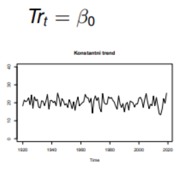

## Lineární trend

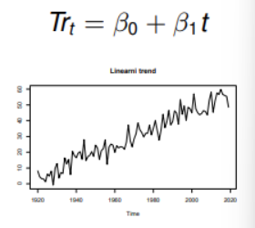

## Kvadratický trend

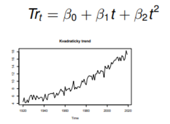

## Exponenciální trend

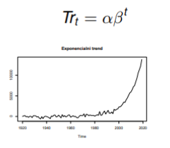

## Logistický trend

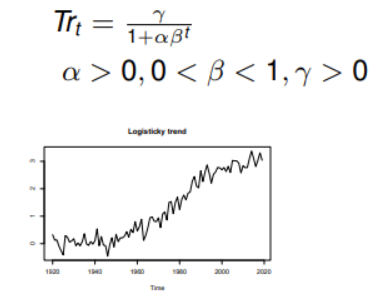

## Gompertzova křivka

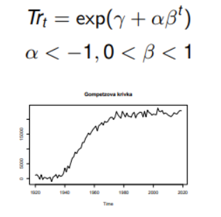

# **Model**

- Model je náš odhadnutý předpis pro časovou řadu
- Snažíme se ho zjistit pro předpovědi časové řady (případně vztahy proměnných, doplnění mezer, …)

## Hodnocení modelu

- U všech následujících měření se snažím docílit co nejnižšího skóre.
- **AIC** (Akaikeho informační kritérium)
  - Preferuje složitější modely
- **AICc** (Akaikeho informační kritérium pro malé vzorky)
  - Doslova AIC pro malé vzorky
- **BIC** (Bayesovské informační kritérium)
  - preferuje jednodušší modely